# employee-data-predicting-attrition

```python
# This Python 3 environment comes with many helpful analytics libraries installed
# It is defined by the kaggle/python Docker image: https://github.com/kaggle/docker-python
# For example, here's several helpful packages to load

import numpy as np # linear algebra
import pandas as pd # data processing, CSV file I/O (e.g. pd.read_csv)

# Input data files are available in the read-only "../input/" directory
# For example, running this (by clicking run or pressing Shift+Enter) will list all files under the input directory

import os
for dirname, _, filenames in os.walk('/kaggle/input'):
    for filename in filenames:
        print(os.path.join(dirname, filename))

# You can write up to 20GB to the current directory (/kaggle/working/) that gets preserved as output when you create a version using "Save & Run All"
# You can also write temporary files to /kaggle/temp/, but they won't be saved outside of the current session
```

```
/kaggle/input/employeedataset/employee_engagement_survey_data.csv
/kaggle/input/employeedataset/training_and_development_data.csv
/kaggle/input/employeedataset/employee_data.csv
/kaggle/input/employeedataset/recruitment_data.csv
```

```python
import datetime as dt
import seaborn as sns
from math import ceil, floor
import matplotlib.pyplot as plt
%pip install pypair
%pip install prince
%pip install association_metrics

pd.set_option("display.max_columns", 50)
pd.set_option("display.max_columns", 100)
```

```python
engagement = pd.read_csv(r'/kaggle/input/employeedataset/employee_engagement_survey_data.csv')
training = pd.read_csv(r'/kaggle/input/employeedataset/training_and_development_data.csv')
employee = pd.read_csv(r'/kaggle/input/employeedataset/employee_data.csv')
recruitment = pd.read_csv(r'/kaggle/input/employeedataset/recruitment_data.csv')
```

# Problem

As a hypothetical organization, we are interested in determining which employee factors are predictive of attrition. We will first begin with a simple EDA of the datasets and attempt to discover any patterns that might allow us to develop a hypothesis. Then we will build a model and test its predictive ability.

## Current Attrition Rates

```python
employee.head()
```

|  | EmpID | FirstName | LastName | StartDate | ExitDate | Title | Supervisor | ADEmail | BusinessUnit | EmployeeStatus | EmployeeType | PayZone | EmployeeClassificationType | TerminationType | TerminationDescription | DepartmentType | Division | DOB | State | JobFunctionDescription | GenderCode | LocationCode | RaceDesc | MaritalDesc | Performance Score | Current Employee Rating |
| --- | --- | --- | --- | --- | --- | --- | --- | --- | --- | --- | --- | --- | --- | --- | --- | --- | --- | --- | --- | --- | --- | --- | --- | --- | --- | --- |
| 0 | 3427 | Uriah | Bridges | 20-Sep-19 | NaN | Production Technician I | Peter Oneill | uriah.bridges@bilearner.com | CCDR | Active | Contract | Zone C | Temporary | Unk | NaN | Production | Finance & Accounting | 07-10-1969 | MA | Accounting | Female | 34904 | White | Widowed | Fully Meets | 4 |
| 1 | 3428 | Paula | Small | 11-Feb-23 | NaN | Production Technician I | Renee Mccormick | paula.small@bilearner.com | EW | Active | Contract | Zone A | Part-Time | Unk | NaN | Production | Aerial | 30-08-1965 | MA | Labor | Male | 6593 | Hispanic | Widowed | Fully Meets | 3 |
| 2 | 3429 | Edward | Buck | 10-Dec-18 | NaN | Area Sales Manager | Crystal Walker | edward.buck@bilearner.com | PL | Active | Full-Time | Zone B | Part-Time | Unk | NaN | Sales | General - Sga | 06-10-1991 | MA | Assistant | Male | 2330 | Hispanic | Widowed | Fully Meets | 4 |
| 3 | 3430 | Michael | Riordan | 21-Jun-21 | NaN | Area Sales Manager | Rebekah Wright | michael.riordan@bilearner.com | CCDR | Active | Contract | Zone A | Full-Time | Unk | NaN | Sales | Finance & Accounting | 04-04-1998 | ND | Clerk | Male | 58782 | Other | Single | Fully Meets | 2 |
| 4 | 3431 | Jasmine | Onque | 29-Jun-19 | NaN | Area Sales Manager | Jason Kim | jasmine.onque@bilearner.com | TNS | Active | Contract | Zone A | Temporary | Unk | NaN | Sales | General - Con | 29-08-1969 | FL | Laborer | Female | 33174 | Other | Married | Fully Meets | 3 |

```python
employee.info(verbose=True)
```

```
<class 'pandas.core.frame.DataFrame'>
RangeIndex: 3000 entries, 0 to 2999
Data columns (total 26 columns):
 #   Column                      Non-Null Count  Dtype
---  ------                      --------------  -----
 0   EmpID                       3000 non-null   int64
 1   FirstName                   3000 non-null   object
 2   LastName                    3000 non-null   object
 3   StartDate                   3000 non-null   object
 4   ExitDate                    1533 non-null   object
 5   Title                       3000 non-null   object
 6   Supervisor                  3000 non-null   object
 7   ADEmail                     3000 non-null   object
 8   BusinessUnit                3000 non-null   object
 9   EmployeeStatus              3000 non-null   object
```

[output cut: 18 more lines]

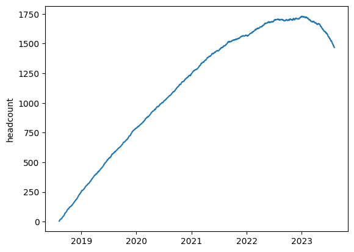

```python
employee[['StartDate', 'ExitDate']] = employee[['StartDate', 'ExitDate']].apply(pd.to_datetime)

start_count = employee.copy().groupby('StartDate').count().iloc[:,0]
end_count = employee.copy().groupby('ExitDate').count().iloc[:,0]

date_range = pd.date_range(min(employee.StartDate.dropna()), max(employee.ExitDate.dropna()))
attr_frame = pd.DataFrame(
    index=date_range
)

attr_frame['starting'] = start_count
attr_frame['leaving'] = end_count
attr_frame.fillna(0, inplace=True)

attr_frame['headcount'] = attr_frame['starting'].expanding().sum() - attr_frame['leaving'].expanding().sum()

attr_frame

sns.lineplot(
    attr_frame
    , x=date_range
    , y='headcount'
)
```

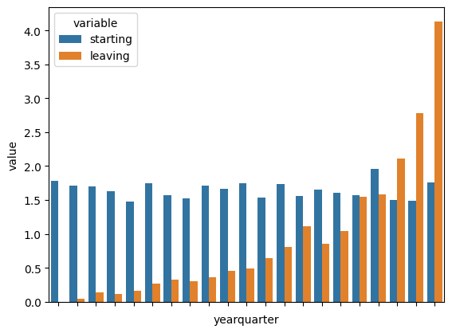

```python
%matplotlib inline
combi = pd.melt(attr_frame.drop('headcount', axis=1), ignore_index=False).reset_index()
combi['month'] = combi['index'].dt.strftime('%m')
combi['quarter'] = combi['month'].astype('int') / 3
combi['quarter'] = combi['quarter'].apply(ceil)
combi['yearquarter'] = combi['index'].dt.strftime('%Y').astype('int') * 100 + combi['quarter']

ax = sns.barplot(combi, x='yearquarter', y='value', hue='variable', errorbar=None)
ax.set(xticklabels=[])

ax
```

Organizing the data by quarter, we see that the rate of hires is relatively constant, but exits are increasing almost exponentially.

## Attrition Reasons

Next we might be interested in understanding the major reasons for attrition, and if we can find any patterns of interest it might lead to a hypothesis. We would start by understanding distributions of the dataset features and picking out or creating those that give insight into attrition.

```python
employee['Performance Score'].value_counts()
```

```
Performance Score
Fully Meets          2361
Exceeds               369
Needs Improvement     177
PIP                    93
Name: count, dtype: int64
```

```python
employee.describe(include='all')
```

|  | EmpID | FirstName | LastName | StartDate | ExitDate | Title | Supervisor | ADEmail | BusinessUnit | EmployeeStatus | EmployeeType | PayZone | EmployeeClassificationType | TerminationType | TerminationDescription | DepartmentType | Division | DOB | State | JobFunctionDescription | GenderCode | LocationCode | RaceDesc | MaritalDesc | Performance Score | Current Employee Rating |
| --- | --- | --- | --- | --- | --- | --- | --- | --- | --- | --- | --- | --- | --- | --- | --- | --- | --- | --- | --- | --- | --- | --- | --- | --- | --- | --- |
| count | 3000.000000 | 3000 | 3000 | 3000 | 1533 | 3000 | 3000 | 3000 | 3000 | 3000 | 3000 | 3000 | 3000 | 3000 | 1533 | 3000 | 3000 | 3000 | 3000 | 3000 | 3000 | 3000.000000 | 3000 | 3000 | 3000 | 3000.000000 |
| unique | NaN | 1597 | 1137 | NaN | NaN | 32 | 2952 | 2998 | 10 | 5 | 3 | 3 | 3 | 5 | 1533 | 6 | 25 | 2800 | 28 | 83 | 2 | NaN | 5 | 4 | 4 | NaN |
| top | NaN | Harley | Preston | NaN | NaN | Production Technician I | John Smith | larissa.warner@bilearner.com | NEL | Active | Full-Time | Zone A | Temporary | Unk | Me see picture nature degree benefit. | Production | Field Operations | 25-12-1991 | MA | Laborer | Female | NaN | Asian | Single | Fully Meets | NaN |
| freq | NaN | 9 | 10 | NaN | NaN | 1321 | 3 | 2 | 304 | 2458 | 1038 | 1062 | 1033 | 1467 | 1 | 2020 | 789 | 4 | 2651 | 522 | 1682 | NaN | 629 | 772 | 2361 | NaN |
| mean | 2500.500000 | NaN | NaN | 2021-01-31 16:03:21.600000256 | 2022-05-21 08:29:07.162426624 | NaN | NaN | NaN | NaN | NaN | NaN | NaN | NaN | NaN | NaN | NaN | NaN | NaN | NaN | NaN | NaN | 44997.180667 | NaN | NaN | NaN | 2.969000 |
| min | 1001.000000 | NaN | NaN | 2018-08-07 00:00:00 | 2018-11-19 00:00:00 | NaN | NaN | NaN | NaN | NaN | NaN | NaN | NaN | NaN | NaN | NaN | NaN | NaN | NaN | NaN | NaN | 1013.000000 | NaN | NaN | NaN | 1.000000 |
| 25% | 1750.750000 | NaN | NaN | 2019-11-03 18:00:00 | 2021-10-09 00:00:00 | NaN | NaN | NaN | NaN | NaN | NaN | NaN | NaN | NaN | NaN | NaN | NaN | NaN | NaN | NaN | NaN | 17546.000000 | NaN | NaN | NaN | 2.000000 |
| 50% | 2500.500000 | NaN | NaN | 2021-02-08 00:00:00 | 2022-09-15 00:00:00 | NaN | NaN | NaN | NaN | NaN | NaN | NaN | NaN | NaN | NaN | NaN | NaN | NaN | NaN | NaN | NaN | 44150.500000 | NaN | NaN | NaN | 3.000000 |
| 75% | 3250.250000 | NaN | NaN | 2022-05-01 00:00:00 | 2023-04-10 00:00:00 | NaN | NaN | NaN | NaN | NaN | NaN | NaN | NaN | NaN | NaN | NaN | NaN | NaN | NaN | NaN | NaN | 71481.250000 | NaN | NaN | NaN | 3.000000 |
| max | 4000.000000 | NaN | NaN | 2023-08-06 00:00:00 | 2023-08-06 00:00:00 | NaN | NaN | NaN | NaN | NaN | NaN | NaN | NaN | NaN | NaN | NaN | NaN | NaN | NaN | NaN | NaN | 98052.000000 | NaN | NaN | NaN | 5.000000 |
| std | 866.169729 | NaN | NaN | NaN | NaN | NaN | NaN | NaN | NaN | NaN | NaN | NaN | NaN | NaN | NaN | NaN | NaN | NaN | NaN | NaN | NaN | 29987.331783 | NaN | NaN | NaN | 1.015078 |

Unfortunately it looks like the `Supervisor` field is not useable as it has 2952 unique values which is not realistic to an organization, meaning almost a 1:1 contributor to manager relationship. Ordinarily this might be interesting if we believed that there might be high attrition associated with a specific manager.

```python
employee.columns
```

```
Index(['EmpID', 'FirstName', 'LastName', 'StartDate', 'ExitDate', 'Title',
       'Supervisor', 'ADEmail', 'BusinessUnit', 'EmployeeStatus',
       'EmployeeType', 'PayZone', 'EmployeeClassificationType',
       'TerminationType', 'TerminationDescription', 'DepartmentType',
       'Division', 'DOB', 'State', 'JobFunctionDescription', 'GenderCode',
       'LocationCode', 'RaceDesc', 'MaritalDesc', 'Performance Score',
       'Current Employee Rating'],
      dtype='object')
```

```python
# more nonsense values
employee[employee.EmployeeStatus == 'Future Start'].head()
```

|  | EmpID | FirstName | LastName | StartDate | ExitDate | Title | Supervisor | ADEmail | BusinessUnit | EmployeeStatus | EmployeeType | PayZone | EmployeeClassificationType | TerminationType | TerminationDescription | DepartmentType | Division | DOB | State | JobFunctionDescription | GenderCode | LocationCode | RaceDesc | MaritalDesc | Performance Score | Current Employee Rating |
| --- | --- | --- | --- | --- | --- | --- | --- | --- | --- | --- | --- | --- | --- | --- | --- | --- | --- | --- | --- | --- | --- | --- | --- | --- | --- | --- |
| 20 | 3447 | Mariela | Schultz | 2020-05-26 | 2023-06-18 | Area Sales Manager | Michelle Evans MD | mariela.schultz@bilearner.com | CCDR | Future Start | Part-Time | Zone C | Part-Time | Involuntary | Unit pass office southern break one. | Sales | General - Con | 17-02-1964 | TX | Technician | Female | 43481 | Asian | Widowed | Fully Meets | 3 |
| 21 | 3448 | Angela | Molina | 2019-10-01 | 2020-11-06 | Area Sales Manager | Patricia Cook | angela.molina@bilearner.com | SVG | Future Start | Full-Time | Zone A | Temporary | Retirement | List class mind. | Sales | Engineers | 12-05-1958 | TX | Specialist | Male | 50705 | Asian | Widowed | Fully Meets | 3 |
| 22 | 3449 | Gerald | Preston | 2023-05-10 | 2023-05-27 | Area Sales Manager | Ashley Reeves | gerald.preston@bilearner.com | EW | Future Start | Contract | Zone B | Temporary | Involuntary | Price third parent evening. | Sales | General - Eng | 18-09-1992 | CO | Technician | Male | 5168 | Black | Single | Fully Meets | 5 |
| 31 | 3458 | Cory | Robinson | 2022-04-28 | 2023-05-24 | Area Sales Manager | Elizabeth Anderson | cory.robinson@bilearner.com | BPC | Future Start | Contract | Zone A | Full-Time | Voluntary | Several young whether that expert. | Sales | Field Operations | 12-08-1996 | TX | Laborer | Female | 5194 | Hispanic | Single | Needs Improvement | 3 |
| 32 | 3459 | Saniya | Yu | 2021-04-18 | 2022-06-21 | Area Sales Manager | Erin Bailey | saniya.yu@bilearner.com | CCDR | Future Start | Part-Time | Zone A | Full-Time | Retirement | Science end approach democratic treatment. | Sales | General - Con | 09-02-1944 | TX | Splicer | Male | 8779 | Black | Widowed | Exceeds | 2 |

```python
employee[['EmployeeStatus','TerminationType']].value_counts()
```

```
EmployeeStatus          TerminationType
Active                  Unk                1467
                        Resignation         252
                        Voluntary           251
                        Involuntary         244
                        Retirement          244
Voluntarily Terminated  Involuntary          86
                        Voluntary            85
                        Retirement           76
                        Resignation          74
Leave of Absence        Retirement           24
Future Start            Retirement           23
Leave of Absence        Voluntary            22
Terminated for Cause    Resignation          22
                        Involuntary          21
Leave of Absence        Resignation          21
                        Involuntary          19
Future Start            Involuntary          18
                        Voluntary            17
Terminated for Cause    Voluntary            13
Future Start            Resignation          11
Terminated for Cause    Retirement           10
Name: count, dtype: int64
```

## Notes on limitations of the dataset

Inspecting some of the other values, we see some more nonsense data. For example, the `EmployeeStatus` field has a value of Future Start for employees with both a valid start and end date. Furthermore, Active candidates have a Termination value. This field is not worth cleaning, instead we should verify that the ExitDate and TerminationType are sensible, because the same information is inferred from these values as we would get from `EmployeeStatus`. `TerminationDescription` seem to just be filler text and is unusable as well. Lastly, `EmployeeType` and `EmployeeClassificationType` are seemingly contradictory in determinng Full and Part-Time employees. We'll just pick `EmployeeType` for the sake of simplicity. Though we might generally be interested in state-by-state differences, because it will add a large number of classes and is tedious for the sake of example, we'll drop `State` as well and just treat `PayZone` to mean the region. `JobFunctionDescription` contradicts the `Title`, and `BusinessUnit` Does not appear useable.

```python
# verifying all exit dates have a termination type
employee[employee.ExitDate.notna()]['TerminationType'].value_counts(dropna=False)
```

```
TerminationType
Involuntary    388
Voluntary      388
Resignation    380
Retirement     377
Name: count, dtype: int64
```

```python
# removing leaky / unusable columns
emp_features = employee.copy().drop(
    ['EmpID','FirstName','LastName','ADEmail', 'Supervisor', 'TerminationDescription', 'EmployeeStatus', 'EmployeeClassificationType', 'State', 'TerminationType', 'LocationCode', 'Title', 'BusinessUnit', 'Division', 'JobFunctionDescription']
    , axis = 1
)
```

## Engineering Features

Now that we have cleaned out some of the value-less features, we can derive additional information. For example, we might be interested in the age and tenure of employees leaving the org. In some scenarios, it might inform us that an aging workforce puts the org at risk of high attrition due to retirement, for example (though based on what we've seen from the earlier data, it's likely this was randomly generated and I'm anticipating seeing retirees in young groups, maybe our org has a lot of lottery winners). For the sake of this analysis, we will take the last date in the dataset and set the "current date" for our calculations.

```python
current_date = emp_features.ExitDate.max()

emp_features['DOB'] = emp_features['DOB'].apply(pd.to_datetime, dayfirst=True)

emp_features['Age'] = emp_features['DOB'].apply(lambda x: floor((current_date - x).days /  325.2425)) # approximate age is good enough


def get_tenure(df):
    df['Cur'] = current_date
    if pd.isnull(df['ExitDate']):
        return df['Cur'] - df['StartDate']
    else:
        return df['ExitDate'] - df['StartDate']
emp_features['Tenure'] = emp_features.apply(get_tenure, axis=1).dt.days

emp_features['Exit'] = emp_features['ExitDate'].isna()

perf_order = {
    'PIP': 0
    , 'Needs Improvement': 1
    , 'Fully Meets': 2
    , 'Exceeds': 3
}
emp_features['OrderedPerformance'] = emp_features['Performance Score'].replace(perf_order)

emp_features.drop(
    ['StartDate','ExitDate', 'DOB','Performance Score']
    , axis=1
    ,  inplace=True
)
```

```python
emp_features.info()
```

[output not shown]

# Correlations

We next will look at correlations between the features and turnover. We have a combination of nominal, ordinal, and continuous IV, and a binary DV (whether or not the employee left).

We will use the appropriate tests for these combinatons:

continuous:

- Age
- Tenure

ordinal:

- Performance Score
- Current Employee Rating

All the rest are nominal, which will require further transformation if the class sizes are too large to meaningfully interpret.

For the continuous IV, dichotomous DV, we will use Point-Biserial correlation. For ordinal IV, dichotomous DV, we use Rank-Biserial.

```
Age : Exit r = -0.00325208331491513, p = 0.8586835694793088
Tenure : Exit r = 0.40302604216427973, p = 1.4657770360063491e-117
```

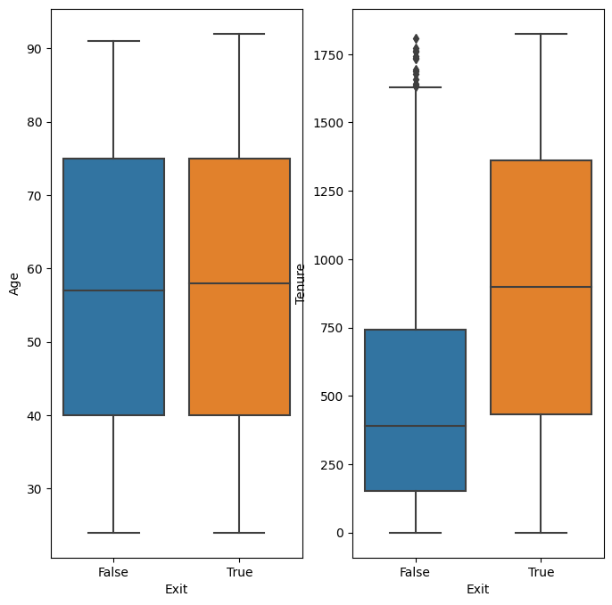

```python
## Point-Bisereal
import matplotlib.pyplot as plt

from scipy.stats import pointbiserialr

y = ['Age','Tenure']
x = emp_features.Exit

fig, axs = plt.subplots(ncols=2, figsize=(8,8))
n=0

for iv in y:
    varr = emp_features[iv]
    pbr = pointbiserialr(x, varr)
    print(f'{iv} : Exit r = {pbr[0]}, p = {pbr[1]}')
    sns.boxplot(
        emp_features
        , y=iv
        , x='Exit'
        , ax = axs[n]
    )
    n += 1
```

We notice a statistically significant relationship and moderate positive correlation between Tenure and Exit. There is not a statistically significant relationship between Age and Exit.

```
Current Employee Rating
3    1530
2     510
4     419
1     271
5     270
Name: count, dtype: int64
Current Employee Rating : Exit r = -1e-05
OrderedPerformance
2    2361
3     369
1     177
0      93
Name: count, dtype: int64
OrderedPerformance : Exit r = 9.5e-07
```

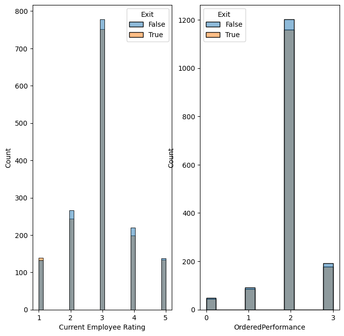

```python
## Rank-Biserial

from pypair.association import binary_continuous

y = ['Current Employee Rating', 'OrderedPerformance']
n=0
fig, axs = plt.subplots(ncols=2, figsize=(8,8))
for iv in y:
    varr = emp_features[iv]
    print(varr.value_counts())
    rbr = binary_continuous(x, varr,'rank_biserial')
    print(f'{iv} : Exit r = {rbr:.2}')
    sns.histplot(
        emp_features
        , x=iv
        , ax = axs[n]
        , hue='Exit'
    )
    n += 1
```

There appears to be no relationship betweeen either categorical variables and Exit. We can consider dropping these variables altogether.

# Nominal fields

We are dealing with nominal with high cardinality which will create challenges with interprability. In order to analyze with a regression, we will need to first see if there are features we can eliminate due to collinearity, then if we still have highly cardinal features we can try to reduce them with a technique like Correspondence Analysis.

```python
emp_features.columns
nom_feat = emp_features[
    ['EmployeeType','PayZone','DepartmentType','GenderCode','RaceDesc','MaritalDesc']
]
```

```python
import prince

mca = prince.MCA(
    n_components=6
    , n_iter=20
    , copy=True
    , check_input=True
    , engine='sklearn'
    , random_state=42
)

mca.fit(nom_feat)

mca.eigenvalues_summary
```

| component | eigenvalue | % of variance | % of variance (cumulative) |
| --- | --- | --- | --- |
| 0 | 0.206 | 7.26% | 7.26% |
| 1 | 0.189 | 6.68% | 13.95% |
| 2 | 0.183 | 6.47% | 20.42% |
| 3 | 0.179 | 6.31% | 26.72% |
| 4 | 0.175 | 6.17% | 32.89% |
| 5 | 0.173 | 6.11% | 39.00% |

```python
emp_features['Tenure'] / 364.25
```

```
0       3.887440
1       0.483185
2       4.667124
3       2.130405
4       4.115305
          ...
2995    0.126287
2996    2.610844
2997    1.655456
2998    2.413178
2999    1.279341
Name: Tenure, Length: 3000, dtype: float64
```

```python
dummy = pd.get_dummies(emp_features, columns=['EmployeeType','PayZone','DepartmentType','GenderCode','RaceDesc','MaritalDesc'], drop_first=True)

dummy
```

|  | Current Employee Rating | Age | Tenure | Exit | OrderedPerformance | EmployeeType_Full-Time | EmployeeType_Part-Time | PayZone_Zone B | PayZone_Zone C | DepartmentType_Executive Office | DepartmentType_IT/IS | DepartmentType_Production | DepartmentType_Sales | DepartmentType_Software Engineering | GenderCode_Male | RaceDesc_Black | RaceDesc_Hispanic | RaceDesc_Other | RaceDesc_White | MaritalDesc_Married | MaritalDesc_Single | MaritalDesc_Widowed |
| --- | --- | --- | --- | --- | --- | --- | --- | --- | --- | --- | --- | --- | --- | --- | --- | --- | --- | --- | --- | --- | --- | --- |
| 0 | 4 | 60 | 1416 | True | 2 | False | False | False | True | False | False | True | False | False | False | False | False | False | True | False | False | True |
| 1 | 3 | 65 | 176 | True | 2 | False | False | False | False | False | False | True | False | False | True | False | True | False | False | False | False | True |
| 2 | 4 | 35 | 1700 | True | 2 | True | False | True | False | False | False | False | True | False | True | False | True | False | False | False | False | True |
| 3 | 2 | 28 | 776 | True | 2 | False | False | False | False | False | False | False | True | False | True | False | False | True | False | False | True | False |
| 4 | 3 | 60 | 1499 | True | 2 | False | False | False | False | False | False | False | True | False | False | False | False | True | False | True | False | False |
| ... | ... | ... | ... | ... | ... | ... | ... | ... | ... | ... | ... | ... | ... | ... | ... | ... | ... | ... | ... | ... | ... | ... |
| 2995 | 3 | 28 | 46 | False | 2 | False | True | False | True | False | False | True | False | False | False | False | False | True | False | False | False | True |
| 2996 | 3 | 24 | 951 | True | 2 | False | True | False | False | False | False | True | False | False | True | True | False | False | False | False | False | True |
| 2997 | 2 | 29 | 603 | False | 2 | False | False | True | False | False | False | True | False | False | True | False | False | False | True | False | True | False |
| 2998 | 2 | 77 | 879 | False | 2 | False | False | True | False | False | False | True | False | False | False | False | True | False | False | False | False | False |
| 2999 | 2 | 36 | 466 | True | 2 | True | False | True | False | False | False | True | False | False | False | False | False | False | True | True | False | False |

3000 rows × 22 columns

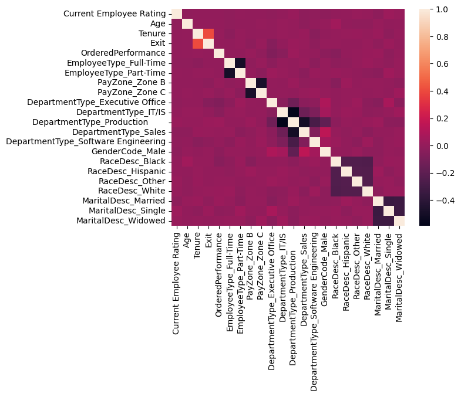

```python
dummy_corr = dummy.corr()
sns.heatmap(dummy_corr)
```

```python
dummy_corr['Exit'].sort_values()
```

```
DepartmentType_Executive Office       -0.050421
PayZone_Zone B                        -0.022244
DepartmentType_Software Engineering   -0.018182
MaritalDesc_Married                   -0.014687
DepartmentType_IT/IS                  -0.008126
Current Employee Rating               -0.007571
EmployeeType_Full-Time                -0.005021
Age                                   -0.003252
MaritalDesc_Widowed                   -0.002412
RaceDesc_Other                        -0.001008
RaceDesc_Hispanic                      0.000496
OrderedPerformance                     0.001285
EmployeeType_Part-Time                 0.003571
GenderCode_Male                        0.007387
RaceDesc_Black                         0.007911
DepartmentType_Sales                   0.010942
RaceDesc_White                         0.011825
PayZone_Zone C                         0.012866
MaritalDesc_Single                     0.020580
DepartmentType_Production              0.025906
Tenure                                 0.403026
Exit                                   1.000000
Name: Exit, dtype: float64
```

across the board we see poor correlations among the variables. In fact, the only feature with a large correlation would be Tenure, which we determined previously. Furthermore, it would be difficult to recommend any further engineering of features because of the poor relationships / colinearity. For the sake of completing the analysis, we will run a logistic regression using only Tenure as a predictor.

```python
import statsmodels.api as sm
log_reg = sm.Logit(emp_features['Exit'], emp_features['Tenure']).fit()

log_reg.summary()
```

```
Optimization terminated successfully.
         Current function value: 0.667809
         Iterations 4
```

Logit Regression Results

| Dep. Variable: | Exit | No. Observations: | 3000 |
| --- | --- | --- | --- |
| Model: | Logit | Df Residuals: | 2999 |
| Method: | MLE | Df Model: | 0 |
| Date: | Sat, 09 Nov 2024 | Pseudo R-squ.: | 0.03622 |
| Time: | 15:08:24 | Log-Likelihood: | -2003.4 |
| converged: | True | LL-Null: | -2078.7 |
| Covariance Type: | nonrobust | LLR p-value: | nan |

|  | coef | std err | z | P>\|z\| | [0.025 | 0.975] |
| --- | --- | --- | --- | --- | --- | --- |
| Tenure | 0.0005 | 4.51e-05 | 11.954 | 0.000 | 0.000 | 0.001 |

While there is a significant result, it is somewhat difficult to interpret. We can convert the `Tenure` from days to years which should help reduce the range of values and make a little more sense.

```python
emp_features['Tenure_years'] = emp_features['Tenure'] / 364.2425
log_reg = sm.Logit(emp_features['Exit'], emp_features['Tenure_years']).fit()

log_reg.summary()
```

```
Optimization terminated successfully.
         Current function value: 0.667809
         Iterations 4
```

Logit Regression Results

| Dep. Variable: | Exit | No. Observations: | 3000 |
| --- | --- | --- | --- |
| Model: | Logit | Df Residuals: | 2999 |
| Method: | MLE | Df Model: | 0 |
| Date: | Sat, 09 Nov 2024 | Pseudo R-squ.: | 0.03622 |
| Time: | 15:41:38 | Log-Likelihood: | -2003.4 |
| converged: | True | LL-Null: | -2078.7 |
| Covariance Type: | nonrobust | LLR p-value: | nan |

|  | coef | std err | z | P>\|z\| | [0.025 | 0.975] |
| --- | --- | --- | --- | --- | --- | --- |
| Tenure_years | 0.1966 | 0.016 | 11.954 | 0.000 | 0.164 | 0.229 |

```python
import math
exp_c = math.exp(.1966)
exp_c
```

```
1.2172570404961613
```

# Discussion